# Swedish Birth Register Analysis

The SBR contains data on all births from 2002 to 2005.

Here, we want to know if head circumference in boys changes between 2002 and 2005.

1. Sample sizes are large, so we can take an ANOVA test.

```r
table(SBR2$year)
```

```
 2002  2003  2004  2005
48364 50159 51739 51339
```

2. Means and variances are similar, so we’re confident that the difference in variances will not be significant.

```r
tapply(SBR2$head, SBR2$year, mean, na.rm = T)
```

```
    2002     2003     2004     2005
35.23045 35.31483 35.27654 35.27393
```

```r
tapply(SBR2$head, SBR2$year, var, na.rm = T)
```

```
    2002     2003     2004     2005
3.229198 3.235278 3.184767 3.206313
```

3. So, let’s check formally whether between-group differences in variances are significant or not, using a Bartlett’s Test:

```r
bartlett.test(SBR2$head ~ SBR2$year)
```

```
    Bartlett test of homogeneity of variances

data:  SBR2$head by SBR2$year
Bartlett's K-squared = 3.7236, df = 3, p-value = 0.2929
```

The p-value is > 0.05, so variances are equal.

4. Histograms for every year look normal:

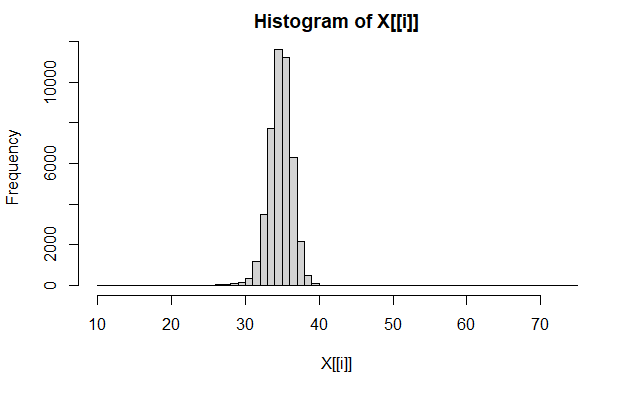

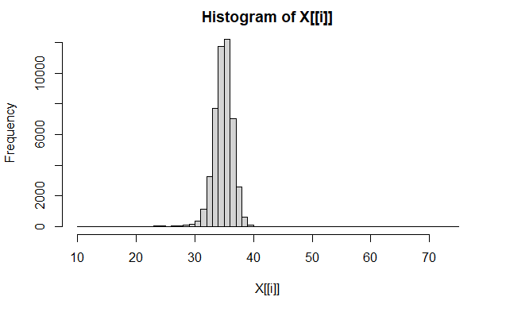

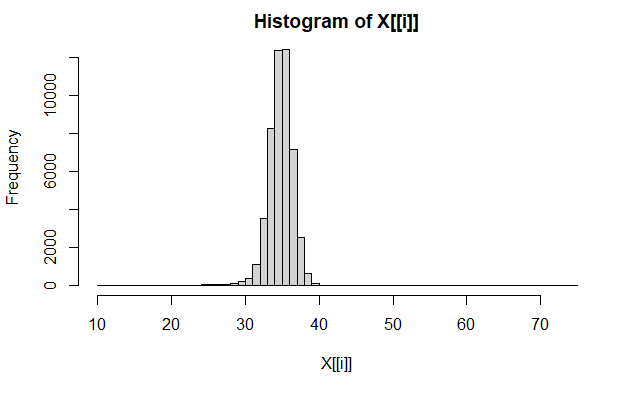

[output not shown]

[output cut: 124 more lines]

[output not shown]

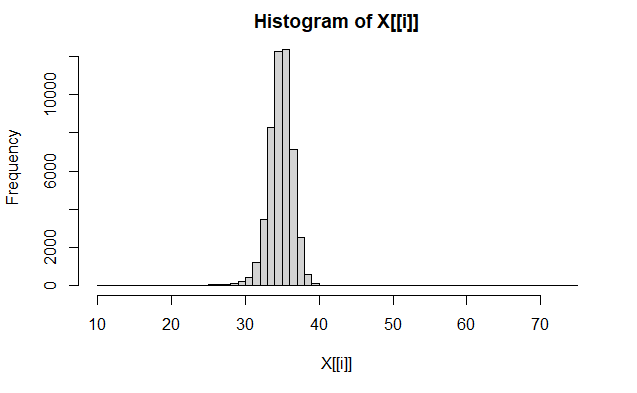

```r
tapply(SBR2$head, SBR2$year, hist, breaks = seq(10,75,1))
```

5. Therefore, we can proceed checking for differences with a parametric ANOVA test:

```r
anova(lm(SBR2$head ~ SBR2$year))
```

```
Analysis of Variance Table

Response: SBR2$head
              Df Sum Sq Mean Sq F value    Pr(>F)
SBR2$year      3    165  55.081  17.141 3.987e-11 ***
Residuals 190857 613297   3.213
---
Signif. codes:  0 ‘***’ 0.001 ‘**’ 0.01 ‘*’ 0.05 ‘.’ 0.1 ‘ ’ 1
```

The result is that there are significant differences in head circumference across the years. This is said by p-value << 0.05.

6. Where are these differences? This can be detected throught a parametric pairwise t-test:

```r
pairwise.t.test(SBR2$head, SBR2$year)
```

```
    Pairwise comparisons using t tests with pooled SD

data:  SBR2$head and SBR2$year

  1       2       3
2 4.7e-12 -       -
3 0.00039 0.00181 -
4 0.00079 0.00120 0.81952

P value adjustment method: holm
```

Analyzing this table, the conclusion is that years 2004-2005 are similar, and the significant differences are caused by years 2002 and 2003.